# Sesión #4: Pegado de Multibases

# Enunciado

[interactive chart not shown]

# Solución Propuesta

### Base de Datos

Descargar Base de DAtos

## Antes de comenzar: Organización de los directorios (Una vez mas)

Folders

## Preambulo y directorios

Lo primero que debemos realizar es lo usual en un preambulo, que es *clear all* y *set more off*. El primero permite operar con un Stata completamrnte vacío y el segundo permite no tener que clickear en *more* cuando ejecutemos programas muy largos.

```
//===========================================================================//
//      TALLER STATA SESION #4
//      AUTOR: ALVARO GUTIERREZ VARGAS
//      FECHA ULTIMA MODIFICACION : 03-04-2018
//===========================================================================//
//  PRELIMINARES
clear all  /*Elimina todo en Stata (base de datos, matrices, locals, etc)*/
set more off  /*Impide que tengamos que estar clickeando "more" cuando el do es muy largo*/
```

Ahora solo nos queda anclar las carpetas que hemos generado con variables globales, de la siguiente forma.

```
//===========================================================================//
//  GLOBALS
    global data_row = "C:\tu_ruta\ROW DATA"
    global data_prepared "C:\tu_ruta\PREPARED DATA"
```

# Merge:

## Pregunta (a)

Acá pordras Descargar Base de Datos que ocuparemos en esta parte.

Para consolidar la base de datos que se le ha entrgado con la base inicial, debemos darnos cuenta que el *unique identifier* que nos permitirá pegar ambas bases es la variable **id**.Por lo que pegaremos ambas bases ocupando el comando [merge](https://www.stata.com/manuals13/dmerge.pdf).

```
merge 1:1 id using "$data_prepared\merge_firms_to_add" , gen(merge_1_1)
```

La linea anterior, luego de invocar al comando merge, se lee de la siguiente forma:

1. *1:1* hace alusión a la forma en la que haremos el pegado de la base de datos. Esta indica que las observaciones se encuentran sin duplicados en cada una de las bases. En otras palabras, solo contamos con una observación para cada una de las firmas en cada una de las bases.
2. using “_$data_prepared*firms_to_add*“: Nos indica que le pegado se realizará usando la base de datos *merge_firms_to_add*. La cual se encuentra alojada dentro de la carpeta *data_prepared* la que anclamos con los global al inicio de nuestro programa.
3. , gen(merge_1_1): Primero acá debemos notar que al existir una coma, estamos entrando al dominio de las **opciones** del comando. Es decir, le estamos agregando opciones que son optativas para el comando merge. En este caso, le estamod indicango que genere (*gen*) una variable llamada **merge_1_1** la cual será una variable útil para analizar el resultado de nuestro pegado. Lo discutiremos en más detalle a cuando veamos el output del comando.

El output que obtenemos al correr el comando anterior corresponde a:

```
merge 1:1 id using "$data_row\merge_firms_to_add" , gen(merge_1_1)

    Result                           # of obs.
    -----------------------------------------
    not matched                             0
    matched                               191  (merge_1_1==3)
    -----------------------------------------

save  "$data_prepared\merge_firms_complete" ,replace


file C:\tu_ruta\PREPARED DATA\merge_firms_complete.dta saved
```

Este nos indica, que de las 191 observaciones que posee la base que teníamos precargada (*merge_firms*), 191 estuvieron presentes en la base que le adicionamos (merge_firms_to_add). Cabe destacar que en el lenguaje del comando [merge](https://www.stata.com/manuals13/dmerge.pdf), la base que tenemos precargada Stata la denomina “Master” y la que le adicionamos es la llamana “Using”.

Finalmente, grabamos esta nueva base consolidada con el nombre *merge_firms_complete.dta* en la carpeta alojada en nuestro global “*data_prepared*”

## Pregunta (b)

Acá pordras Descargar Base de Datos que ocuparemos en esta parte.

Ahora lo que debemos realizar es el pegado de una base de datos que contiene una dimesión inferior a la que tenemos cargada, tal como se puede apreciar en la figura del enunciado. Por ende, no podremos realizar un pegado 1:1. Dado que no tendremos una observacion en la base *using* para cada una de las observaciones de la base *master*. De este modo, dado que la base de datos que queremos agregar a la *master* posee una dimensión inferior, la única forma de que esta operación sea posible(manteniendo las dimensiones de la base master) es que las observaciones de la base *using* se repitan hasta alcanzar el número de filas en *master*. De esta forma, dado que queremos agregar información que representa solo al país al cual pertenece la firma. Tendremos que cada fila de *using* que se repetirá para todas las observaciones de ese país en *master*. Con lo que al correr la siguiente linea generaremos el pegado.

```
merge m:1 country using "$data_row\merge_countries" , gen(merge_m_1)


   Result                           # of obs.
    -----------------------------------------
    not matched                            20
        from master                        20  (merge_m_1==1)
        from using                          0  (merge_m_1==2)

    matched                               171  (merge_m_1==3)
    -----------------------------------------
```

La lectura del output es la siguiente, se puede apreciar que existieron 20 observaciones que no fueron **matched** (primera linea: *not matched*) de las cuales 20 de la base *master* no tuvieron correspondencia en la base *master* y cero en *using*. Para ver esto más claramente analicemos la siguiente imagen que fue generada con el comando.

```
br id CompanyCommonName country inflation tax_rate population merge_m_1
```

Desde esta fgura podemos colegir lo siguiente:

1. Vemos no teníamos información sobre PERÚ en la base *using*, por lo que las filas correspondientes a las firmas de ese país, no contienen la información de *inflation*, *tax_rate* ni *population*
2. Por otro lado, vemos lo que habíamos comentado en el parrafo anterior.Toda la información contenida para MÉXICO, en la base *using* fue repetida para cada una de las firmas que se ubican en dicho país.
3. En base al punto anterior, podemos hacer explícito que el pegado fue un **m:1** debido a que, en la terminolgía del Stata, lo que realizamos fue un *MANY* to *ONE*. Lo que en términos prácticos, significa que a muchas filas de la base *master* le pegamos la misma fila de la base *using*.

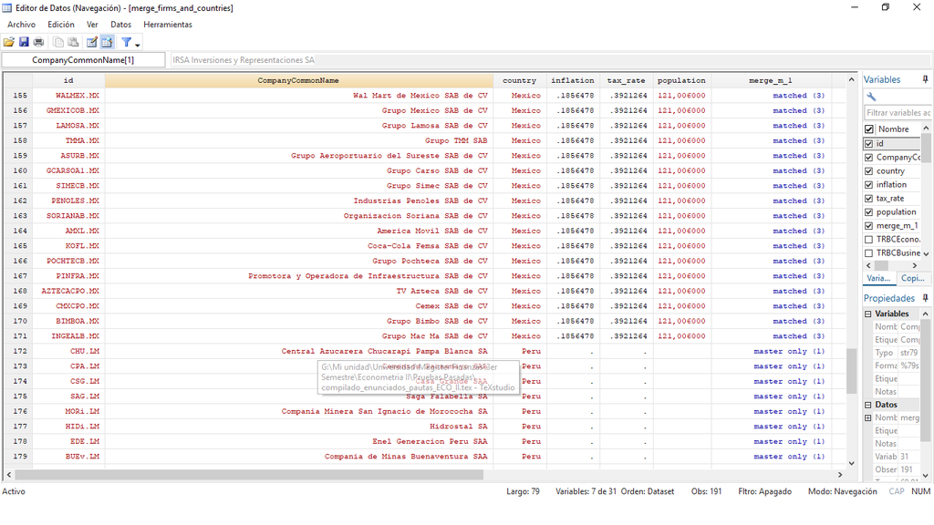

   Finalmente, guardamos la base que acabamos de generar como:

## Pregunta (c)

Acá pordras Descargar Base de Datos que ocuparemos en esta parte.

Finalmente, para realizar el pegado de la última base, cambiamos la forma de pegado, dado que ahora agregaremos más *filas* a la base de datos (lo que hicimos anteriormente fue agregar más *columnas*) Ahora lo que debemos hacer se resume en las dos lineas siguientes.

```
use  "$data_prepared\merge_firms_and_countries" ,replace

append using "$data_row\append_2013"
```

El comando [append](https://www.stata.com/manuals13/dappend.pdf), lo que nos permite es agregar más filas, ocupando como *Unique Indetifier* el nombre de las columnas de nuestras bases de datos. Con lo que adherirá las filas de la base *using* a las columnas que corresponda, en nuestra base *master*.

## Pregunta (d)

En caso de que hubieramos tenido cargada la base *merge_countries* en vez de *merge_firms_complete*, lo unico que hubiera cambiado, es que el pegado hubiera sido **1:m**, debido a que ahora le pegaremos *MANY* filas to *ONE* fila en nuestra base *master* (De hecho, en este caso, nuestra base *master* solo contaría con 5 observaciones).

```
 use  "$data_row\merge_countries" , clear

 merge 1:m country using  "$data_prepared\merge_firms_complete"  , gen(merge_1_m)

    Result                           # of obs.
    -----------------------------------------
    not matched                            20
        from master                         0  (merge_1_m==1)
        from using                         20  (merge_1_m==2)

    matched                               171  (merge_1_m==3)
    -----------------------------------------
```